# Exploratory Data Analysis (EDA) for Four Year Graduation

## Data Preparation and EDA

First File to Run Open Libraries

```r
library("ggplot2", lib.loc="/Library/Frameworks/R.framework/Versions/3.4/Resources/library")
library("graphics", lib.loc="/Library/Frameworks/R.framework/Versions/3.4/Resources/library")
library("gplots", lib.loc="/Library/Frameworks/R.framework/Versions/3.4/Resources/library")
library("dplyr")
library("lattice", lib.loc="/Library/Frameworks/R.framework/Versions/3.4/Resources/library")
library("data.table", lib.loc="/Library/Frameworks/R.framework/Versions/3.4/Resources/library")
library("datasets")
library("readxl")
library("stats")
```

Import data set

```r
setwd("~/REGIS/Practicum I/RStudio")
dataSet <- read_excel("./dataSet.xlsx")
#View(dataSet)
```

Transform data set into data frame

```r
dfDataSet <- as.data.frame(dataSet)
head(dfDataSet)
```

|  | Year of OriginalMajorDate | GraduationStatus | YearsFromOMD | CsGrad | 4YG | 5YG | 6YG | 1_CSCI101 | 1_MATH111 | 2_CSCI261 | 2_MATH112 | 2_MATH201 | 3_CSCI262 | 3_MATH213 | 4_CSCI341 | 4_CSCI358 | 4_MATH225 | 5_CSCI306 | 5_CSCI403 | 5_MATH332 | 6_CSCI406 | 7_CSCI370 | 8_CSCI400 | 9_CSCI442 |
| --- | --- | --- | --- | --- | --- | --- | --- | --- | --- | --- | --- | --- | --- | --- | --- | --- | --- | --- | --- | --- | --- | --- | --- | --- |
| 1 | 2014 | Graduated | 4.00 | Yes | Yes | Yes | Yes | 4 | 3 | 4.0 | 2 | 3 | 3 | 4 | 2 | 4 | 4 | 3.0 | 4 | 3 | 2.0 | 3.3 | 3.3 | 2.3 |
| 2 | 2008 | Graduated | 9.84 | OtherMajor | No | Yes | Yes | NA | 3 | 4.0 | 2 | 3 | NA | 3 | NA | NA | 3 | NA | NA | NA | NA | NA | NA | NA |
| 3 | 2008 | InactiveReg | 9.84 | NG | No | No | No | NA | 3 | 4.0 | 2 | 2 | 1 | 2 | 2 | 3 | 1 | NA | NA | 2 | NA | NA | NA | NA |
| 4 | 2011 | InactiveReg | 6.84 | NG | No | No | No | NA | 3 | 3.3 | 4 | NA | 3 | 2 | 2 | 2 | 4 | 3.7 | 3 | 3 | 0.3 | NA | 3.3 | NA |
| 5 | 2008 | Graduated | 9.84 | OtherMajor | Yes | Yes | Yes | NA | 3 | 4.0 | 3 | 3 | NA | 3 | NA | NA | 4 | NA | NA | NA | NA | NA | NA | NA |
| 6 | 2008 | Graduated | 9.84 | Yes | Yes | Yes | Yes | 4 | 3 | 3.0 | 3 | 2 | 3 | 4 | 3 | 2 | 3 | 4.0 | 4 | 3 | 2.0 | 4.0 | 3.0 | 3.0 |

```r
head(dfDataSet)
```

|  | Year of OriginalMajorDate | GraduationStatus | YearsFromOMD | CsGrad | 4YG | 5YG | 6YG | 1_CSCI101 | 1_MATH111 | 2_CSCI261 | 2_MATH112 | 2_MATH201 | 3_CSCI262 | 3_MATH213 | 4_CSCI341 | 4_CSCI358 | 4_MATH225 | 5_CSCI306 | 5_CSCI403 | 5_MATH332 | 6_CSCI406 | 7_CSCI370 | 8_CSCI400 | 9_CSCI442 |
| --- | --- | --- | --- | --- | --- | --- | --- | --- | --- | --- | --- | --- | --- | --- | --- | --- | --- | --- | --- | --- | --- | --- | --- | --- |
| 1 | 2014 | Graduated | 4.00 | Yes | Yes | Yes | Yes | 4 | 3 | 4.0 | 2 | 3 | 3 | 4 | 2 | 4 | 4 | 3.0 | 4 | 3 | 2.0 | 3.3 | 3.3 | 2.3 |
| 2 | 2008 | Graduated | 9.84 | OtherMajor | No | Yes | Yes | NA | 3 | 4.0 | 2 | 3 | NA | 3 | NA | NA | 3 | NA | NA | NA | NA | NA | NA | NA |
| 3 | 2008 | InactiveReg | 9.84 | NG | No | No | No | NA | 3 | 4.0 | 2 | 2 | 1 | 2 | 2 | 3 | 1 | NA | NA | 2 | NA | NA | NA | NA |
| 4 | 2011 | InactiveReg | 6.84 | NG | No | No | No | NA | 3 | 3.3 | 4 | NA | 3 | 2 | 2 | 2 | 4 | 3.7 | 3 | 3 | 0.3 | NA | 3.3 | NA |
| 5 | 2008 | Graduated | 9.84 | OtherMajor | Yes | Yes | Yes | NA | 3 | 4.0 | 3 | 3 | NA | 3 | NA | NA | 4 | NA | NA | NA | NA | NA | NA | NA |
| 6 | 2008 | Graduated | 9.84 | Yes | Yes | Yes | Yes | 4 | 3 | 3.0 | 3 | 2 | 3 | 4 | 3 | 2 | 3 | 4.0 | 4 | 3 | 2.0 | 4.0 | 3.0 | 3.0 |

```r
summary(dfDataSet)
```

```
 Year of OriginalMajorDate GraduationStatus   YearsFromOMD          CsGrad              4YG                5YG
 Length:536                Length:536         Length:536         Length:536         Length:536         Length:536
 Class :character          Class :character   Class :character   Class :character   Class :character   Class :character
 Mode  :character          Mode  :character   Mode  :character   Mode  :character   Mode  :character   Mode  :character




     6YG              1_CSCI101       1_MATH111      2_CSCI261       2_MATH112       2_MATH201       3_CSCI262      3_MATH213
 Length:536         Min.   :0.300   Min.   :0.30   Min.   :0.300   Min.   :0.300   Min.   :0.300   Min.   :0.30   Min.   :0.300
 Class :character   1st Qu.:3.000   1st Qu.:3.00   1st Qu.:3.000   1st Qu.:2.000   1st Qu.:2.000   1st Qu.:3.00   1st Qu.:2.000
 Mode  :character   Median :4.000   Median :3.00   Median :4.000   Median :3.000   Median :3.000   Median :4.00   Median :3.000
                    Mean   :3.419   Mean   :2.91   Mean   :3.405   Mean   :2.875   Mean   :2.701   Mean   :3.24   Mean   :2.888
                    3rd Qu.:4.000   3rd Qu.:3.00   3rd Qu.:4.000   3rd Qu.:4.000   3rd Qu.:3.300   3rd Qu.:4.00   3rd Qu.:4.000
                    Max.   :4.000   Max.   :4.00   Max.   :4.000   Max.   :4.000   Max.   :4.000   Max.   :4.00   Max.   :4.000
                    NA's   :76      NA's   :12     NA's   :37      NA's   :26      NA's   :108     NA's   :81     NA's   :49
   4_CSCI341       4_CSCI358       4_MATH225       5_CSCI306       5_CSCI403       5_MATH332       6_CSCI406       7_CSCI370
 Min.   :0.300   Min.   :0.300   Min.   :0.300   Min.   :0.300   Min.   :0.300   Min.   :0.300   Min.   :0.300   Min.   :2.300
 1st Qu.:2.000   1st Qu.:2.000   1st Qu.:2.000   1st Qu.:3.000   1st Qu.:3.000   1st Qu.:2.000   1st Qu.:2.000   1st Qu.:4.000
 Median :3.000   Median :3.000   Median :3.000   Median :3.700   Median :4.000   Median :3.000   Median :3.000   Median :4.000
 Mean   :2.854   Mean   :2.961   Mean   :2.763   Mean   :3.433   Mean   :3.565   Mean   :2.671   Mean   :2.795   Mean   :3.895
 3rd Qu.:4.000   3rd Qu.:4.000   3rd Qu.:4.000   3rd Qu.:4.000   3rd Qu.:4.000   3rd Qu.:3.300   3rd Qu.:3.300   3rd Qu.:4.000
 Max.   :4.000   Max.   :4.000   Max.   :4.000   Max.   :4.000   Max.   :4.000   Max.   :4.000   Max.   :4.000   Max.   :4.000
 NA's   :108     NA's   :108     NA's   :58      NA's   :132     NA's   :250     NA's   :121     NA's   :154     NA's   :179
   8_CSCI400       9_CSCI442
 Min.   :0.300   Min.   :0.300
 1st Qu.:2.925   1st Qu.:3.000
 Median :3.300   Median :3.300
 Mean   :3.175   Mean   :3.133
 3rd Qu.:4.000   3rd Qu.:4.000
 Max.   :4.000   Max.   :4.000
 NA's   :164     NA's   :165
```

Transform Variable’s type to the appropriate data type

```r
dfDataSet[1] <- lapply(dfDataSet[1], as.integer)
dfDataSet[3] <- lapply(dfDataSet[3], as.numeric)
dfDataSet[8:24] <- lapply(dfDataSet[8:24], as.numeric)
dfDataSet[2] <- lapply(dfDataSet[2], as.factor)
dfDataSet[4:7] <- lapply(dfDataSet[4:7], as.factor)
str(dfDataSet)
```

```
'data.frame':   536 obs. of  24 variables:
 $ Year of OriginalMajorDate: int  2014 2008 2008 2011 2008 2008 2008 2008 2008 2008 ...
 $ GraduationStatus         : Factor w/ 3 levels "CurrentStudent",..: 2 2 3 3 2 2 2 2 3 2 ...
 $ YearsFromOMD             : num  4 9.84 9.84 6.84 9.84 9.84 9.84 9.84 9.84 9.84 ...
 $ CsGrad                   : Factor w/ 3 levels "NG","OtherMajor",..: 3 2 1 1 2 3 3 2 1 2 ...
 $ 4YG                      : Factor w/ 2 levels "No","Yes": 2 1 1 1 2 2 2 2 1 2 ...
 $ 5YG                      : Factor w/ 2 levels "No","Yes": 2 2 1 1 2 2 2 2 1 2 ...
 $ 6YG                      : Factor w/ 2 levels "No","Yes": 2 2 1 1 2 2 2 2 1 2 ...
 $ 1_CSCI101                : num  4 NA NA NA NA 4 4 NA NA NA ...
 $ 1_MATH111                : num  3 3 3 3 3 3 4 3 2 3 ...
 $ 2_CSCI261                : num  4 4 4 3.3 4 3 4 3 3 3 ...
 $ 2_MATH112                : num  2 2 2 4 3 3 4 4 2 2 ...
 $ 2_MATH201                : num  3 3 2 NA 3 2 4 NA NA 1 ...
 $ 3_CSCI262                : num  3 NA 1 3 NA 3 4 4 1 NA ...
 $ 3_MATH213                : num  4 3 2 2 3 4 4 4 1 2 ...
 $ 4_CSCI341                : num  2 NA 2 2 NA 3 4 NA 3 3 ...
 $ 4_CSCI358                : num  4 NA 3 2 NA 2 4 NA NA NA ...
 $ 4_MATH225                : num  4 3 1 4 4 3 4 4 NA 1 ...
 $ 5_CSCI306                : num  3 NA NA 3.7 NA 4 4 4 NA NA ...
 $ 5_CSCI403                : num  4 NA NA 3 NA 4 4 NA NA NA ...
 $ 5_MATH332                : num  3 NA 2 3 NA 3 4 NA NA NA ...
 $ 6_CSCI406                : num  2 NA NA 0.3 NA 2 4 NA NA NA ...
 $ 7_CSCI370                : num  3.3 NA NA NA NA 4 4 NA NA NA ...
 $ 8_CSCI400                : num  3.3 NA NA 3.3 NA 3 4 NA NA NA ...
 $ 9_CSCI442                : num  2.3 NA NA NA NA 3 4 NA NA NA ...
```

```r
summary(dfDataSet)
```

```
 Year of OriginalMajorDate       GraduationStatus  YearsFromOMD          CsGrad     4YG       5YG       6YG        1_CSCI101
 Min.   :2008              CurrentStudent: 32     Min.   :3.830   NG        :140   No :252   No :169   No :150   Min.   :0.300
 1st Qu.:2009              Graduated     :396     1st Qu.:4.830   OtherMajor: 57   Yes:284   Yes:367   Yes:386   1st Qu.:3.000
 Median :2011              InactiveReg   :108     Median :6.840   Yes       :339                                 Median :4.000
 Mean   :2011                                     Mean   :6.706                                                  Mean   :3.419
 3rd Qu.:2013                                     3rd Qu.:8.840                                                  3rd Qu.:4.000
 Max.   :2014                                     Max.   :9.840                                                  Max.   :4.000
                                                                                                                 NA's   :76
   1_MATH111      2_CSCI261       2_MATH112       2_MATH201       3_CSCI262      3_MATH213       4_CSCI341       4_CSCI358
 Min.   :0.30   Min.   :0.300   Min.   :0.300   Min.   :0.300   Min.   :0.30   Min.   :0.300   Min.   :0.300   Min.   :0.300
 1st Qu.:3.00   1st Qu.:3.000   1st Qu.:2.000   1st Qu.:2.000   1st Qu.:3.00   1st Qu.:2.000   1st Qu.:2.000   1st Qu.:2.000
 Median :3.00   Median :4.000   Median :3.000   Median :3.000   Median :4.00   Median :3.000   Median :3.000   Median :3.000
 Mean   :2.91   Mean   :3.405   Mean   :2.875   Mean   :2.701   Mean   :3.24   Mean   :2.888   Mean   :2.854   Mean   :2.961
 3rd Qu.:3.00   3rd Qu.:4.000   3rd Qu.:4.000   3rd Qu.:3.300   3rd Qu.:4.00   3rd Qu.:4.000   3rd Qu.:4.000   3rd Qu.:4.000
 Max.   :4.00   Max.   :4.000   Max.   :4.000   Max.   :4.000   Max.   :4.00   Max.   :4.000   Max.   :4.000   Max.   :4.000
 NA's   :12     NA's   :37      NA's   :26      NA's   :108     NA's   :81     NA's   :49      NA's   :108     NA's   :108
   4_MATH225       5_CSCI306       5_CSCI403       5_MATH332       6_CSCI406       7_CSCI370       8_CSCI400       9_CSCI442
 Min.   :0.300   Min.   :0.300   Min.   :0.300   Min.   :0.300   Min.   :0.300   Min.   :2.300   Min.   :0.300   Min.   :0.300
 1st Qu.:2.000   1st Qu.:3.000   1st Qu.:3.000   1st Qu.:2.000   1st Qu.:2.000   1st Qu.:4.000   1st Qu.:2.925   1st Qu.:3.000
 Median :3.000   Median :3.700   Median :4.000   Median :3.000   Median :3.000   Median :4.000   Median :3.300   Median :3.300
 Mean   :2.763   Mean   :3.433   Mean   :3.565   Mean   :2.671   Mean   :2.795   Mean   :3.895   Mean   :3.175   Mean   :3.133
 3rd Qu.:4.000   3rd Qu.:4.000   3rd Qu.:4.000   3rd Qu.:3.300   3rd Qu.:3.300   3rd Qu.:4.000   3rd Qu.:4.000   3rd Qu.:4.000
 Max.   :4.000   Max.   :4.000   Max.   :4.000   Max.   :4.000   Max.   :4.000   Max.   :4.000   Max.   :4.000   Max.   :4.000
 NA's   :58      NA's   :132     NA's   :250     NA's   :121     NA's   :154     NA's   :179     NA's   :164     NA's   :165
```

Transform data frame into a table

```r
tbDataSet <- data.table(dfDataSet)
tbDataSet
```

| Year of OriginalMajorDate | GraduationStatus | YearsFromOMD | CsGrad | 4YG | 5YG | 6YG | 1_CSCI101 | 1_MATH111 | 2_CSCI261 | 2_MATH112 | 2_MATH201 | 3_CSCI262 | 3_MATH213 | 4_CSCI341 | 4_CSCI358 | 4_MATH225 | 5_CSCI306 | 5_CSCI403 | 5_MATH332 | 6_CSCI406 | 7_CSCI370 | 8_CSCI400 | 9_CSCI442 |
| --- | --- | --- | --- | --- | --- | --- | --- | --- | --- | --- | --- | --- | --- | --- | --- | --- | --- | --- | --- | --- | --- | --- | --- |
| 2014 | Graduated | 4.00 | Yes | Yes | Yes | Yes | 4.0 | 3.0 | 4.0 | 2.0 | 3.0 | 3.0 | 4.0 | 2.0 | 4.0 | 4.0 | 3.0 | 4.0 | 3.0 | 2.0 | 3.3 | 3.3 | 2.3 |
| 2008 | Graduated | 9.84 | OtherMajor | No | Yes | Yes | NA | 3.0 | 4.0 | 2.0 | 3.0 | NA | 3.0 | NA | NA | 3.0 | NA | NA | NA | NA | NA | NA | NA |
| 2008 | InactiveReg | 9.84 | NG | No | No | No | NA | 3.0 | 4.0 | 2.0 | 2.0 | 1.0 | 2.0 | 2.0 | 3.0 | 1.0 | NA | NA | 2.0 | NA | NA | NA | NA |
| 2011 | InactiveReg | 6.84 | NG | No | No | No | NA | 3.0 | 3.3 | 4.0 | NA | 3.0 | 2.0 | 2.0 | 2.0 | 4.0 | 3.7 | 3.0 | 3.0 | 0.3 | NA | 3.3 | NA |
| 2008 | Graduated | 9.84 | OtherMajor | Yes | Yes | Yes | NA | 3.0 | 4.0 | 3.0 | 3.0 | NA | 3.0 | NA | NA | 4.0 | NA | NA | NA | NA | NA | NA | NA |
| 2008 | Graduated | 9.84 | Yes | Yes | Yes | Yes | 4.0 | 3.0 | 3.0 | 3.0 | 2.0 | 3.0 | 4.0 | 3.0 | 2.0 | 3.0 | 4.0 | 4.0 | 3.0 | 2.0 | 4.0 | 3.0 | 3.0 |
| 2008 | Graduated | 9.84 | Yes | Yes | Yes | Yes | 4.0 | 4.0 | 4.0 | 4.0 | 4.0 | 4.0 | 4.0 | 4.0 | 4.0 | 4.0 | 4.0 | 4.0 | 4.0 | 4.0 | 4.0 | 4.0 | 4.0 |
| 2008 | Graduated | 9.84 | OtherMajor | Yes | Yes | Yes | NA | 3.0 | 3.0 | 4.0 | NA | 4.0 | 4.0 | NA | NA | 4.0 | 4.0 | NA | NA | NA | NA | NA | NA |
| 2008 | InactiveReg | 9.84 | NG | No | No | No | NA | 2.0 | 3.0 | 2.0 | NA | 1.0 | 1.0 | 3.0 | NA | NA | NA | NA | NA | NA | NA | NA | NA |
| 2008 | Graduated | 9.84 | OtherMajor | Yes | Yes | Yes | NA | 3.0 | 3.0 | 2.0 | 1.0 | NA | 2.0 | 3.0 | NA | 1.0 | NA | NA | NA | NA | NA | NA | NA |

[output cut: 526 more lines]

Create a table for variable “GraduationStatus”

```r
tb <- table(dfDataSet$GraduationStatus)
tb
```

```
CurrentStudent      Graduated    InactiveReg
            32            396            108
```

Create table with percentages of total

```r
tb.prop <- dfDataSet$GraduationStatus %>%
   table() %>%
   prop.table() %>% {. * 100} %>%
   round(2)
tb.prop
```

```
.
CurrentStudent      Graduated    InactiveReg
          5.97          73.88          20.15
```

Create a Pie chart

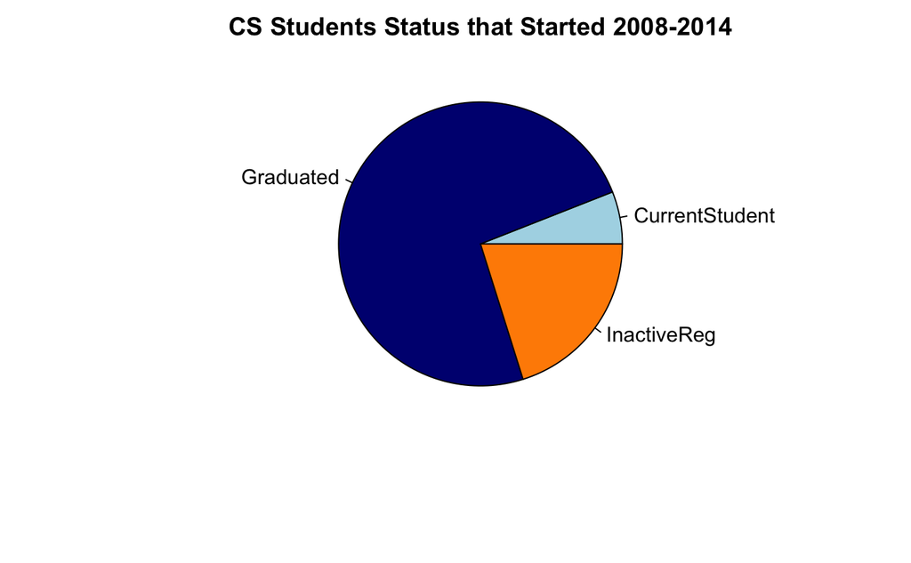

```r
pie(tb, main = "CS Students Status that Started 2008-2014", col = c("Light Blue","Navy Blue","Dark Orange"))
```

Create a Bar chart

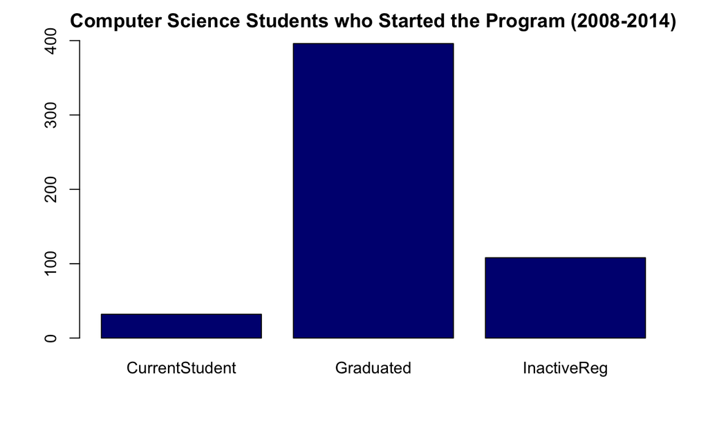

```r
barplot(tb, col = "navy blue", ylim=c(0,400),main = "Computer Science Students who Started the Program (2008-2014)")
```

Create a Bar plot where the “graduated”" students are divided into CS and Other Major students

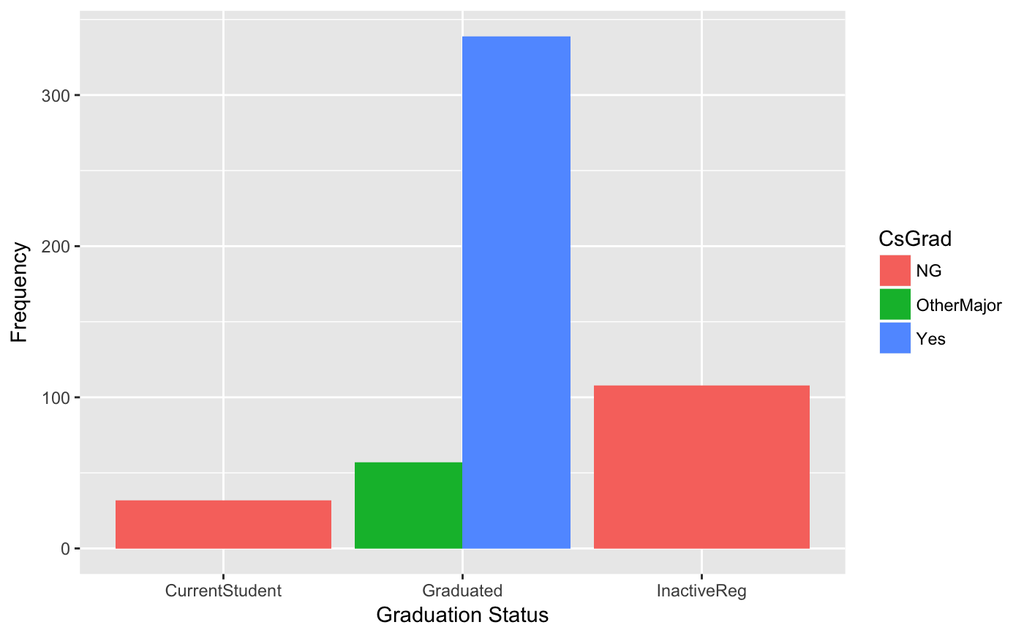

```r
ggplot(dfDataSet) +
  geom_bar(aes(x = factor(GraduationStatus), fill = CsGrad), position = 'dodge') +
  xlab('Graduation Status') + ylab('Frequency')
```

Create a plot to represent the CS students that have graduated in 4 years

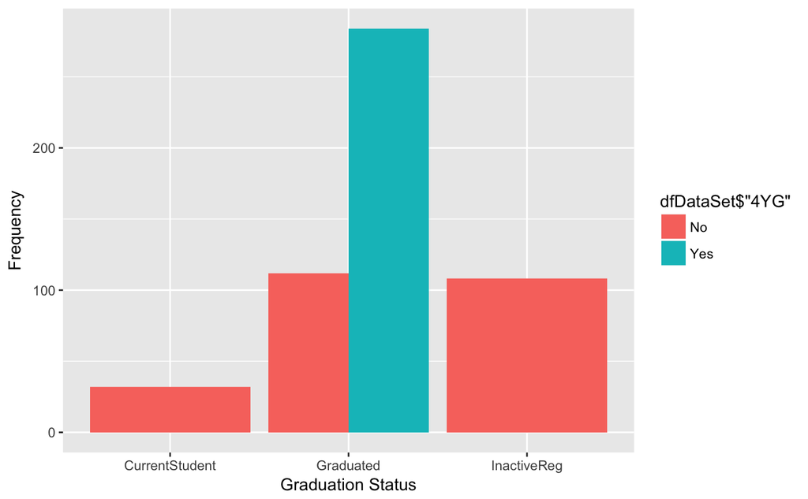

```r
ggplot(dfDataSet) +
  geom_bar(aes(x = factor(GraduationStatus), fill = dfDataSet$"4YG"), position = 'dodge') +
  xlab('Graduation Status') + ylab('Frequency')
```

Create a table of numbers and percetages of students that graduate in 4 years

```r
tb4YG <- table(dfDataSet$"4YG")
tb4YGpercent <- prop.table(tb4YG)
tb4YGpercent
```

```
       No       Yes
0.4701493 0.5298507
```

```r
cbind(tb4YG,prop.table(tb4YG))
```

```
    tb4YG
No    252 0.4701493
Yes   284 0.5298507
```

Create a Pie Chart for Four-year graduation rate

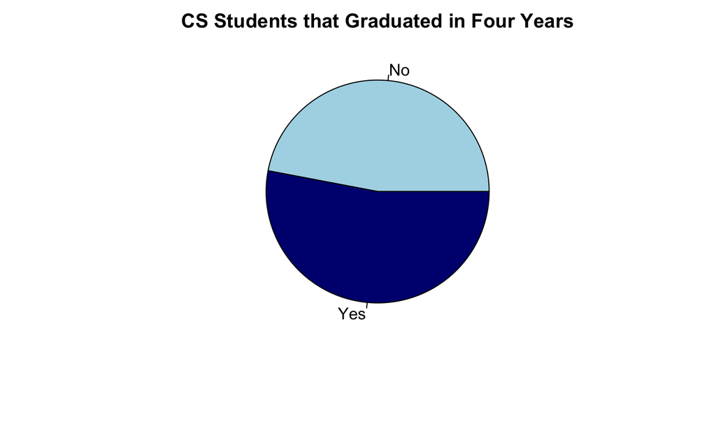

```r
pie(tb4YG, main = "CS Students that Graduated in Four Years", col = c("Light Blue","Navy Blue","Dark Orange"))
```

Create a Bar chart for Four-year graduation rate

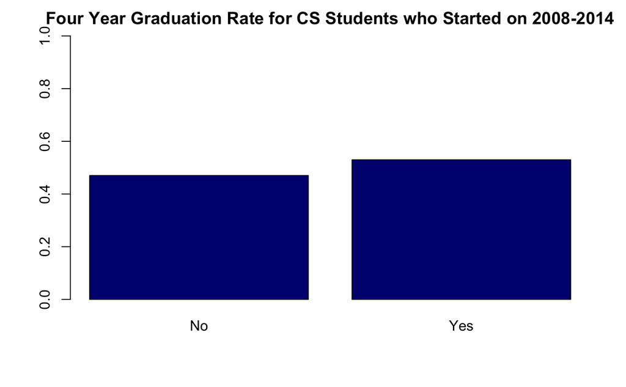

```r
barplot(tb4YGpercent, col = "navy blue", ylim=c(0,1),main = "Four Year Graduation Rate for CS Students who Started on 2008-2014")
```

Create a table of numbers and percetages of students that graduate in 5 years

```r
tb5YG <- table(dfDataSet$"5YG")
tb5YGpercent <- prop.table(tb5YG)
tb5YGpercent
```

```
       No       Yes
0.3152985 0.6847015
```

```r
cbind(tb5YG,prop.table(tb5YG))
```

```
    tb5YG
No    169 0.3152985
Yes   367 0.6847015
```

Create a Pie Chart for Five-year graduation rate

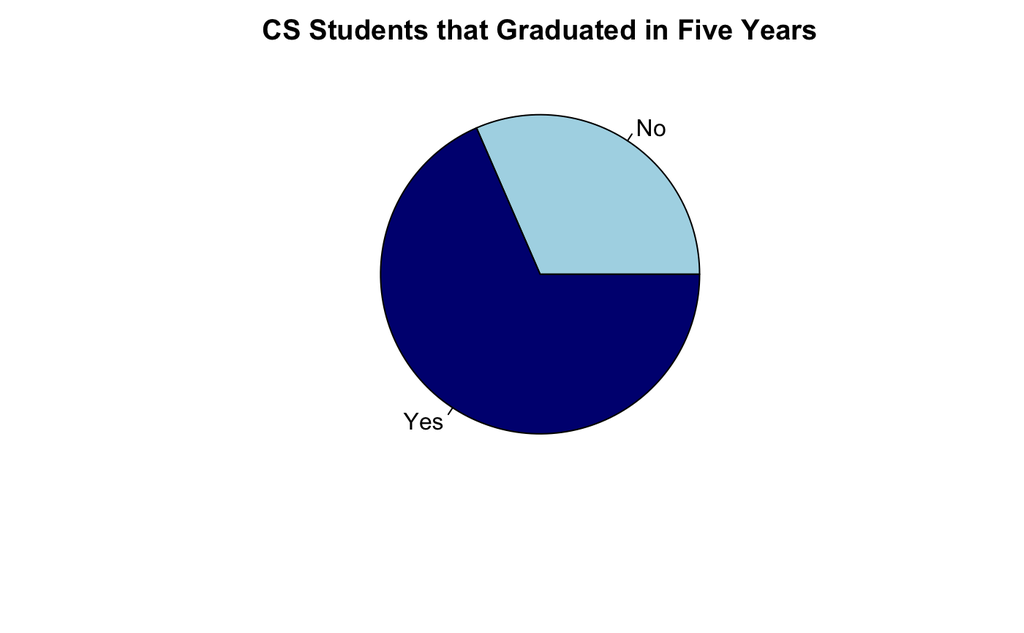

```r
pie(tb5YG, main = "CS Students that Graduated in Five Years", col = c("Light Blue","Navy Blue","Dark Orange"))
```

Create a Bar Chart for Five-year graduation rate

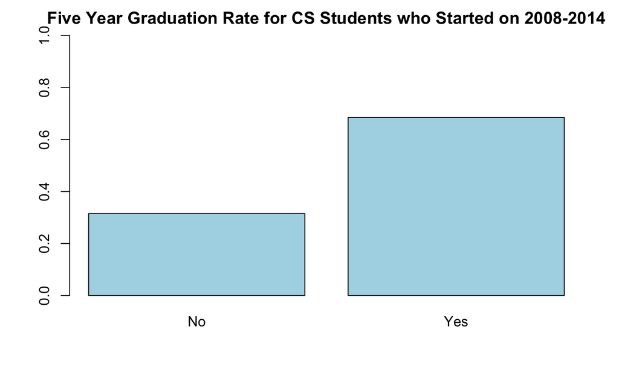

```r
barplot(tb5YGpercent, col = "lightblue", ylim=c(0,1),main = "Five Year Graduation Rate for CS Students who Started on 2008-2014")
```

Create a table of numbers and percetages of students that graduate in 6 years

```r
tb6YG <- table(dfDataSet$"6YG")
tb6YGpercent <- prop.table(tb6YG)
tb6YGpercent
```

```
       No       Yes
0.2798507 0.7201493
```

```r
cbind(tb6YG,prop.table(tb6YG))
```

```
    tb6YG
No    150 0.2798507
Yes   386 0.7201493
```

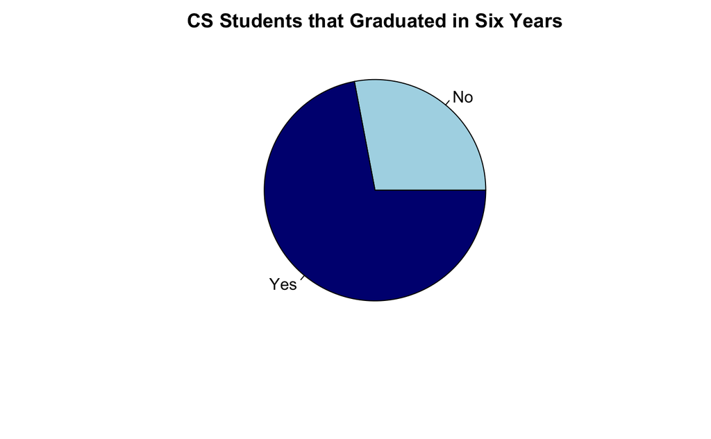

```r
pie(tb6YG, main = "CS Students that Graduated in Six Years", col = c("Light Blue","Navy Blue","Dark Orange"))
```

Create a Bar Chart for Six-year graduation rate

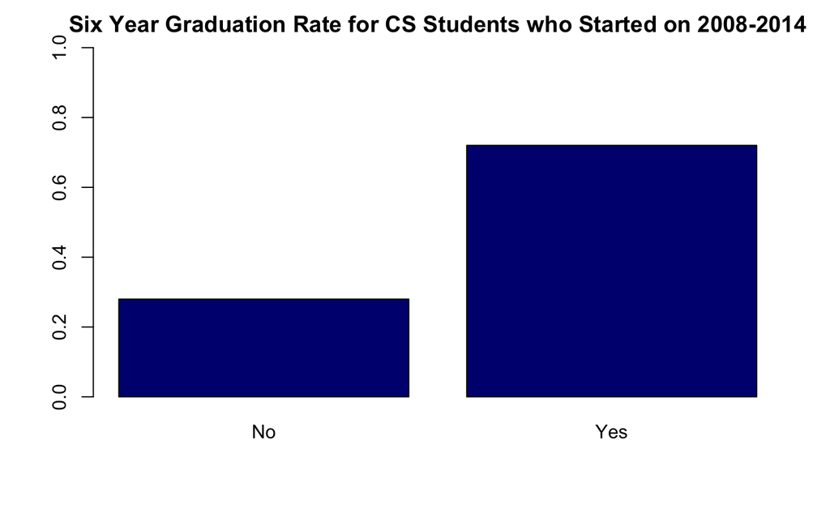

```r
barplot(tb6YGpercent, col = "navy blue", ylim=c(0,1), main = "Six Year Graduation Rate for CS Students who Started on 2008-2014")
```